# Day 2

## String manipulation

## Putting strings together with stringr

- str_c()
- the c is short for concatentate, a function that works like paste()

```r
str_c("Beautiful","day", sep=" ")
```

```
## [1] "Beautiful day"
```

```r
str_c("Beautiful",NA, sep=" ")
```

```
## [1] NA
```

```r
paste("Beautiful",NA, sep=" ") #base R
```

```
## [1] "Beautiful NA"
```

## Length

```r
nchar(c("Bruce", "Wayne"))
```

```
## [1] 5 5
```

```r
stringr::str_length(c("Bruce", "Wayne"))
```

```
## [1] 5 5
```

```r
#factors
f<-factor(c("good","good", "moderate", "bad"))
nchar(f) #nchar throws error
```

```
## Error in nchar(f): 'nchar()' requires a character vector
```

```r
stringr::str_length(f)
```

```
## [1] 4 4 8 3
```

## Extracting substrings

- str_sub()
- extracts parts of strings based on their location
- first argument, string, is a vector of strings
- the arguments start and end specify the boundaries of the piece to extract in characters
- both start and end can be negative integers, in which case, they count from the end of the string

```r
str_sub(c("Bruce", "Wayne"), 1, 4)
```

```
## [1] "Bruc" "Wayn"
```

```r
str_sub(c("Bruce", "Wayne"), -3, -1)
```

```
## [1] "uce" "yne"
```

## Matches

- str_detect(): answers the question: Does the string contain the pattern?
- str_subset(): subsetting strings based on match
- str_count(); counting matches

```r
pizzas <- c("cheese", "pepperoni", "sausage and green peppers")

str_detect(pizzas, pattern = "pepper")
```

```
## [1] FALSE  TRUE  TRUE
```

```r
str_subset(pizzas, pattern = fixed("pepper"))
```

```
## [1] "pepperoni"                 "sausage and green peppers"
```

```r
str_count(pizzas, pattern = fixed("pepper"))
```

```
## [1] 0 1 1
```

```r
str_count(pizzas, pattern = fixed("e"))
```

```
## [1] 3 2 5
```

## Parsing strings into variables

str_split(): pull apart raw string data into more useful variables

```r
date_ranges <- c("23.01.2017 - 29.01.2017", "30.01.2017 - 06.02.2017")

split_dates <- str_split(date_ranges, pattern = fixed(" - "))

split_dates
```

```
## [[1]]
## [1] "23.01.2017" "29.01.2017"
##
## [[2]]
## [1] "30.01.2017" "06.02.2017"
```

## Replacing matches in strings

```r
ids <- c("ID#: 192", "ID#: 118", "ID#: 001")

# Replace "ID#: " with ""
id_nums <- str_replace(ids, "ID#: ", "")

id_nums
```

```
## [1] "192" "118" "001"
```

```r
phone_numbers <- c("510-555-0123", "541-555-0167")

str_replace_all(phone_numbers, "-", ".")
```

```
## [1] "510.555.0123" "541.555.0167"
```

## Lab

- open names.txt and copy the content
- you’ll turn a vector of full names, like “Bruce Wayne”, into abbreviated names like “B. Wayne”. This requires combining str_split(), str_sub() and str_c().
- do task using str_split with simplify=TRUE
- calculate how many names end with a, h, s and e.

## Regular expressions (Advanced)

## Why Regular expressions

- Most commonly when working with strings
- Extracting something from something
- Which number is the following string: `"10202"`?
- Is there a number in a string: `"102a"`? What about in this `"1O2"`?
- We would like to seperate the following string into 3 columns `"2,32.1,0.4"`!

## Regular expressions

- syntax to describe patterns
- functions on patterns

## grep

- grep function from base
- sub for replacment
- stringr package
- `grep` - global regex print. Is there a patern in a string?

```r
string <- "car"
pattern <- "car"
grep(pattern, string)
```

```
## [1] 1
```

```r
string <- c("car", "cars", "in a car", "truck", "car's trunk")
pattern <- "car"
grep(pattern, string)
```

```
## [1] 1 2 3 5
```

## grepl

- `grepl` - returns logical value

```r
string <- c("car", "cars", "in a car", "truck", "car's trunk")
pattern <- "car"
grepl(pattern, string)
```

```
## [1]  TRUE  TRUE  TRUE FALSE  TRUE
```

## Meta and special characters

- special characters: `. \ | ( ) [ { ^ $ * + ?`
- `\`- escape character
- `.` - any (just one) character
- `^` - begining of a string
- `$` - end of string

```r
string <- c("car", "cars", "in a car", "truck", "car's trunk")
grep("^c.r",string)
```

```
## [1] 1 2 5
```

```r
grep("^c..$",string)
```

```
## [1] 1
```

```r
grep("^c.r.$",string)
```

```
## [1] 2
```

## Alphanumeric character

- w

```r
grep("\\w", c(" ", "a", "1", "A", "%", "\t"))
```

```
## [1] 2 3 4
```

```r
grepl("\\w", c(" ", "a", "1", "A", "%", "\t"))
```

```
## [1] FALSE  TRUE  TRUE  TRUE FALSE FALSE
```

## Non - alphanumeric character

- W

```r
grep("\\W", c(" ", "a", "1", "A", "%", "\t"))
```

```
## [1] 1 5 6
```

```r
grepl("\\W", c(" ", "a", "1", "A", "%", "\t"))
```

```
## [1]  TRUE FALSE FALSE FALSE  TRUE  TRUE
```

## Whitespace

- s

```r
grep("\\s", c(" ", "a", "1", "A", "%", "\t"))
```

```
## [1] 1 6
```

## Non - whitespace

- S

```r
grep("\\S", c(" ", "a", "1", "A", "%", "\t"))
```

```
## [1] 2 3 4 5
```

## Digit

- d

```r
grep("\\d", c(" ", "a", "1", "A", "%", "\t"))
```

```
## [1] 3
```

## Non - digit

- D

```r
grep("\\D", c(" ", "a", "1", "A", "%", "\t"))
```

```
## [1] 1 2 4 5 6
```

## Possible values for a character

- using []

```r
grep("^[abc]\\w\\w", c("car", "bus", "no", "cars"))
```

```
## [1] 1 2 4
```

```r
grep("^[abc]\\w\\w$", c("car", "bus", "no", "cars"))
```

```
## [1] 1 2
```

## All n-characters smallcaps words

```r
grep("^[a-z][a-z][a-z]$", c("Car", "Cars",
"cars","car", "no", "three:", "tic", "tac"))
```

```
## [1] 4 7 8
```

## One or two digits anywhere

- `|` - or sign
- `()` - group

```r
grep("((\\d)|([1-9]\\d))", c("1", "20", "0", "zero", "it is 100%", "09"))
```

```
## [1] 1 2 3 5 6
```

## Exactly one or two digits

```r
grep("^((\\d)|([1-9]\\d))$", c("1", "20", "0", "nič", "to je 100%", "09"))
```

```
## [1] 1 2 3
```

```r
grep("^((\\d)|(\\d\\d))$", c("1", "20", "0", "nič", "to je 100%", "09"))
```

```
## [1] 1 2 3 6
```

## Repeating (1)

- repeating operators refer to last character or group
- `?` - matches at most 1 times
- `*` - matches at least 0 times
- `+` - matches at least 1 times
- `{m}` – matches exactly `m` times
- `{m, n}` – matches between `m` and `n` times
- `{m, }` – matches at least `m` times

```r
string <- c("a", "ab", "acb", "accb", "acccb", "accccb")
grep("ac*b", string)
```

```
## [1] 2 3 4 5 6
```

```r
grep("ac+b", string)
```

```
## [1] 3 4 5 6
```

## Repeating (2)

```r
string <- c("a", "ab", "acb", "accb", "acccb", "accccb")
grep("ac?b", string, value=TRUE)
```

```
## [1] "ab"  "acb"
```

```r
grep("ac{2}b", string, value = TRUE)
```

```
## [1] "accb"
```

```r
grep("ac{2,}b", string, value = TRUE)
```

```
## [1] "accb"   "acccb"  "accccb"
```

```r
grep("ac{2,3}b", string, value = TRUE)
```

```
## [1] "accb"  "acccb"
```

## All smallcaps letter words

```r
grep("^([a-z]+ )*[a-z]+$", c("words", "words or sentences",
    "123 no", "Words"," word","word 123"))
```

```
## [1] 1 2
```

## Words with letters and length from 3-5

```r
grep("^[a-z]{3,5}$", c("words", "words or sentences",
    "123 no", "Words"," word","word 123","hey"))
```

```
## [1] 1 7
```

## Signed numbers

```r
grep("^[+-]?(0|[1-9][0-9]*)$", c("++0", "+1", "01", "-99"))
```

```
## [1] 2 4
```

## Greedy and Lazy Repetition

- the repetition operators or quantifiers are greedy
- how to make them lazy?
- regexpr
- regmatches

```r
string<-"This is a <EM>first</EM> test"
pattern<-"<.+>"

r<-regexpr(pattern,string)
regmatches(string, r)
```

```
## [1] "<EM>first</EM>"
```

```r
##lazy
pattern<-"<.+?>"
r<-regexpr(pattern,string)
regmatches(string, r)
```

```
## [1] "<EM>"
```

## Sub-pattern (group catching)

- (….(..(.))..(..(.)…(.))
- “naming” goes from left to right

```r
string <- c("(1,2)", "( -2, 7)", "(    -3   ,     45)", "(a, 3)")
pattern<-"\\(\\s*([+-]?(0|[1-9][0-9]*))\\s*,\\s*([+-]?(0|[1-9][0-9]*))\\s*\\)"

lidx <- !grepl(pattern, string)
komp1 <- sub(pattern, "\\1", string)
komp1[lidx] <- NA
komp2 <- sub(pattern, "\\3", string)
komp2[lidx] <- NA
as.integer(komp1)
```

```
## [1]  1 -2 -3 NA
```

```r
as.integer(komp2)
```

```
## [1]  2  7 45 NA
```

## gregexpr

- finds all positions and lengths of matched patterns

```r
text<-"Yesterday I had 100 Euros, today I only have 45 Euros left."
gregexpr("(\\d+)",text)
```

```
## [[1]]
## [1] 17 46
## attr(,"match.length")
## [1] 3 2
## attr(,"index.type")
## [1] "chars"
## attr(,"useBytes")
## [1] TRUE
```

## regmatches

- extract or replace matched substrings from match data obtained by regexpr, gregexpr or regexec

```r
text<-"Yesterday I had 100 Euros, today I only have 45 Euros left."

regmatches(text, gregexpr("\\d+",text))
```

```
## [[1]]
## [1] "100" "45"
```

## Lab

- Open regular.txt and complete the excercises

## Stringr and regular expressions

- str_subset (grep)

```r
fruit%>%str_subset("\\s")
```

```
##  [1] "bell pepper"       "blood orange"      "canary melon"
##  [4] "chili pepper"      "goji berry"        "kiwi fruit"
##  [7] "purple mangosteen" "rock melon"        "salal berry"
## [10] "star fruit"        "ugli fruit"
```

- str_detect (grepl)
- str_extract/str_extract_all (gregexpr+regmatches)

```r
text<-"Yesterday I had 100 Euros, today I only have 45 Euros left."
str_extract(text,"\\d+")
```

```
## [1] "100"
```

```r
str_extract_all(text,"\\d+")
```

```
## [[1]]
## [1] "100" "45"
```

## Text mining (optional)

## Data

[figure not shown]

```r
include_graphics("./Pictures/Data.png")
```

## Data

[figure not shown]

## Why text mining?

- 85-90 percent of all corporate data is in some kind of unstructured form (e.g., text )
- unstructured corporate data is doubling in size every 18 months
- text Mining Concepts Benefits of text mining are obvious especially in text rich data environments e.g
- law (court orders)
- academic research (research articles)
- finance (quarterly reports)
- medicine (discharge summaries)
- marketing (customer comments)
- electronic communication records (e.g., Email) Spam filtering Email prioritization and categorization Automatic response generation

## Key steps

1. Collection of text document

2. Pre – processing of text

3. Text mining techniques

4. Analyze the text

5. Knowledge discovery

## 1. Collection of text document

- web scraping
- scanning and OCR
- internal documents

## 2. Pre – processing of text

- tokenization
- removal of stop words
- stemming

## Preprocessing: tokenize and N-grams

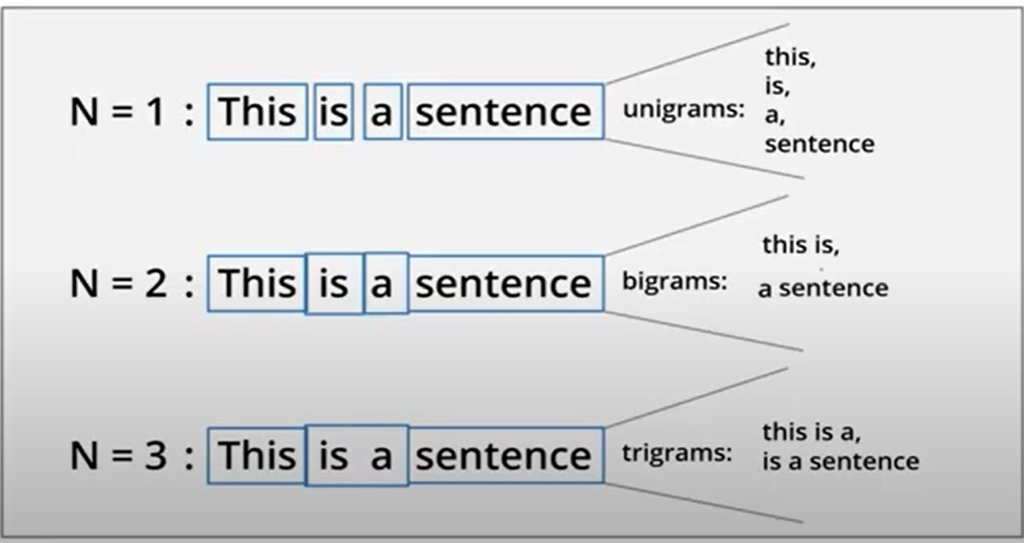

```r
include_graphics("./Pictures/ngrams.jpg")
```

## Tokenize - example

```r
text <- c("Great white shark just ate my leg.","Not a wonderful day and days!")
text_df <- tibble(id = 1:2, text = text)

text_df %>%
  unnest_tokens(word, text)
```

```
## # A tibble: 13 x 2
##       id word
##    <int> <chr>
##  1     1 great
##  2     1 white
##  3     1 shark
##  4     1 just
##  5     1 ate
##  6     1 my
##  7     1 leg
##  8     2 not
##  9     2 a
## 10     2 wonderful
## 11     2 day
## 12     2 and
## 13     2 days
```

## Removal of stop words

- the most common words in any language (like articles, prepositions, pronouns, conjunctions, etc)
- not adding much information to the text
- examples of a few stop words in English are “the”, “a”, “an”, “so”, “what”,…
- why removing stop words; removing the low-level information from our text in order to give more focus to the important information
- *Do we always remove stop words? NO!*
- *Before removing stop words, research a bit about your task and the problem you are trying to solve, and then make your decision!*

## Removal of stop words

```r
data(stop_words)

text_df %>%
  unnest_tokens(word, text) %>%
  anti_join(stop_words)
```

```
## # A tibble: 7 x 2
##      id word
##   <int> <chr>
## 1     1 white
## 2     1 shark
## 3     1 ate
## 4     1 leg
## 5     2 wonderful
## 6     2 day
## 7     2 days
```

## Stemming and lemmatization

- **Stemming**: the process of reducing a word to its stem or root format
- **Lemmatization**: the transformation that uses a dictionary to map a word’s variant back to its root format

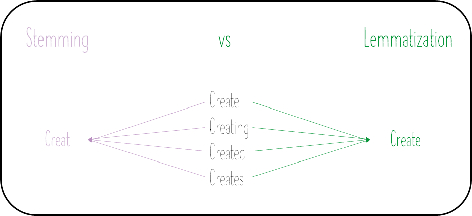

## Stemming and lemmatization

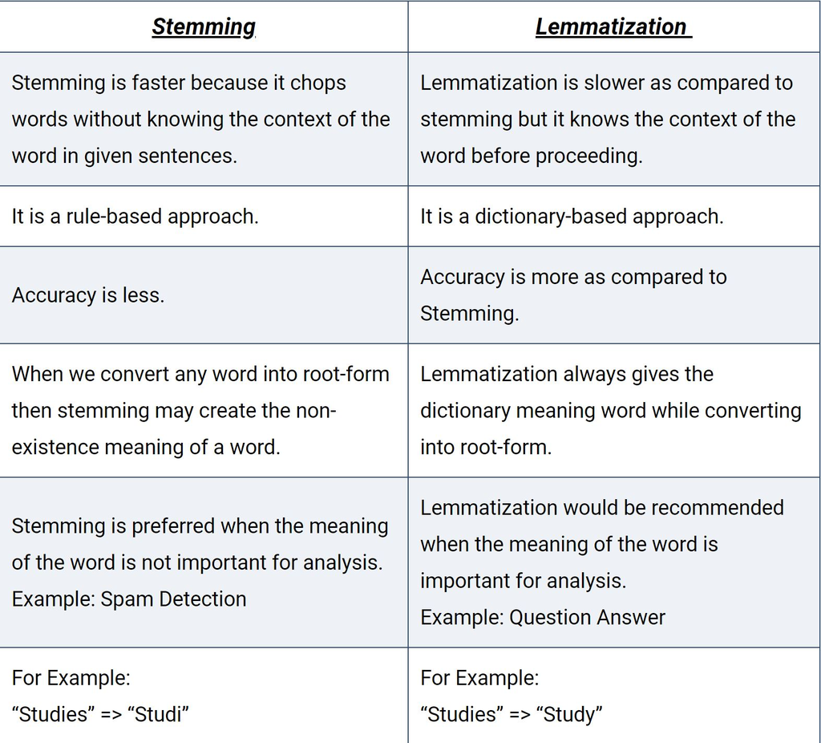

## Stemming and lemmatization - stemming

```r
text_df %>%
  unnest_tokens(word, text) %>%
  mutate(word=wordStem(word))
```

```
## # A tibble: 13 x 2
##       id word
##    <int> <chr>
##  1     1 great
##  2     1 white
##  3     1 shark
##  4     1 just
##  5     1 at
##  6     1 my
##  7     1 leg
##  8     2 not
##  9     2 a
## 10     2 wonder
## 11     2 dai
## 12     2 and
## 13     2 dai
```

## Stemming and lemmatization - lemmatization

```r
text_df %>%
  unnest_tokens(word, text) %>%
  mutate(word=lemmatize_words(word))
```

```
## # A tibble: 13 x 2
##       id word
##    <int> <chr>
##  1     1 great
##  2     1 white
##  3     1 shark
##  4     1 just
##  5     1 eat
##  6     1 my
##  7     1 leg
##  8     2 not
##  9     2 a
## 10     2 wonderful
## 11     2 day
## 12     2 and
## 13     2 day
```

## 3. Text mining techniques

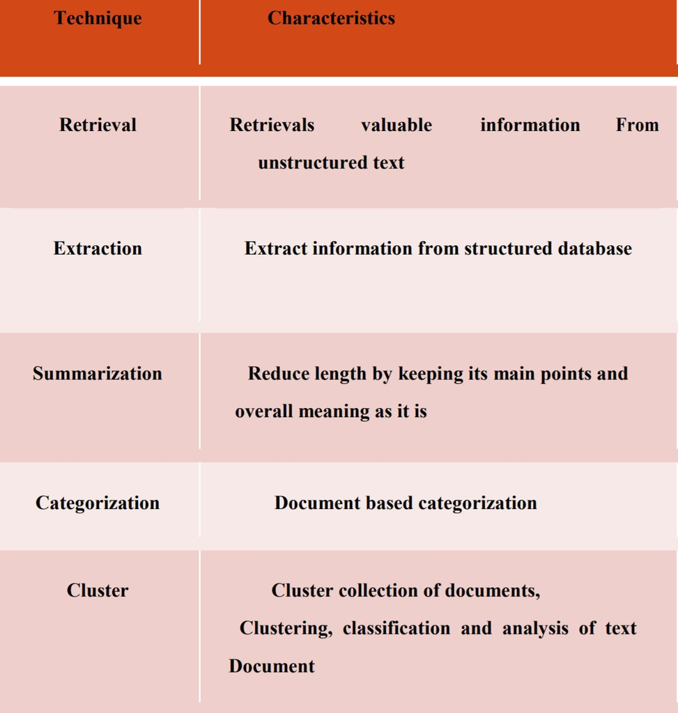

## Concepts

- bag of words
- NLP

## Bag of words

- mostly used technique
- every word is independent (mostly)
- stemming/lemmatization (tourist, tourists and tourism may be the same word)
- word frequency
- POS
- sentiment analysis (different lexicons)
- entities extraction
- topics identification (e.g. LDA algorithm)

## NLP

- uses dictionaries to learn (e.g. Stanford NLP)
- a subfield of artificial intelligence and computational linguistics. the study of “understanding” the natural human language

## Demo

[Stanford NLP](https://corenlp.run/)

## Sentiment analysis

- lexicons
- simple (e.g. Liu&Hu): 1 negative, 0 neutral, +1 positive
- advanced (e.g. AFINN): -5<–>+5

## How to do it in R - 1

- many packages:
  - tm, LDA, textmineR, tidyr, sentimentr,…

```r
data<-read_xlsx("TA_reviews.xlsx")
sentences<- get_sentences(data$fullrev[1:2])
sentences
```

```
## [[1]]
## [1] "The hotel is ideally located and is in a beautiful building."
## [2] "Most of the staff are very polite and helpful."
## [3] "Rooms are comfortable and it has a serviceable gym."
## [4] "Avoid going to breakfast before 0700 or wearing flip flops or slippers, you will be admonished and sent back to your room to change."
##
## [[2]]
## [1] "The hotel is a short walk to the pedestrian mall, restaurants and cafes."
## [2] "The hotel is an old historical landmark."
## [3] "I loved the tall ceilings, lobby and restaurant."
## [4] "The bathroom has been updated and is very nice."
## [5] "The breakfast buffet is very good with many options and you can eat outside."
## [6] "We enjoyed our stay here."
##
## attr(,"class")
## [1] "get_sentences"           "get_sentences_character"
## [3] "list"
```

## How to do it in R - 2

```r
dfJR<-sentiment_by(sentences,polarity_dt=lexicon::hash_sentiment_jockers_rinker)
dfSE<-sentiment_by(sentences,polarity_dt=lexicon::hash_sentiment_sentiword)
dfJR
```

```
##    element_id word_count        sd ave_sentiment
## 1:          1         52 0.3861717     0.2993681
## 2:          2         56 0.2501910     0.2914671
```

```r
dfSE
```

```
##    element_id word_count        sd ave_sentiment
## 1:          1         52 0.1763900    0.14263246
## 2:          2         56 0.1420433    0.02832483
```

## How to do it in R - 3

```r
sentences<-"The great white shark just ate my leg!"

dfJR<-sentiment_by(sentences,polarity_dt=lexicon::hash_sentiment_jockers_rinker)
dfSE<-sentiment_by(sentences,polarity_dt=lexicon::hash_sentiment_sentiword)
dfJR
```

```
##    element_id word_count sd ave_sentiment
## 1:          1          8 NA   -0.03535534
```

```r
dfSE
```

```
##    element_id word_count sd ave_sentiment
## 1:          1          8 NA   -0.04787702
```

## How to deal with datetime

## Creating date/times - 1

- the default format for date is yyyy-mm-dd
- the default format for time is hh:mm:dd
- a date-time is a date plus a time
- native class for storing time: hms package

```r
date<-"2019-05-05"
time<-"18:51:32"

datetime<-paste(date,time)

as.POSIXct(datetime) ## base R
```

```
## [1] "2019-05-05 18:51:32 CEST"
```

```r
as.POSIXlt(datetime) ## base R
```

```
## [1] "2019-05-05 18:51:32 CEST"
```

```r
as_datetime(datetime) ## lubridate
```

```
## [1] "2019-05-05 18:51:32 UTC"
```

## Creating date/times - 2

- to get the current date or date-time you can use today() or now() - same as in Excel
- from a string, from individual date-time components, from an existing date/time object

```r
Sys.Date() ## base
```

```
## [1] "2022-03-02"
```

```r
today() ## lubridate
```

```
## [1] "2022-03-02"
```

```r
Sys.time() ## base
```

```
## [1] "2022-03-02 22:22:28 CET"
```

```r
now()   ## lubridate
```

```
## [1] "2022-03-02 22:22:28 CET"
```

## From strings - 1

- using lubridate

```r
ymd("2017-01-31")
```

```
## [1] "2017-01-31"
```

```r
mdy("Januar 31, 2017")
```

```
## [1] "2017-01-31"
```

```r
dmy("31-Jan-2017")
```

```
## [1] "2017-01-31"
```

```r
dmy("17/10/2018")
```

```
## [1] "2018-10-17"
```

## From strings - 2

```r
ymd_hms("2017-01-31 20:11:59")
```

```
## [1] "2017-01-31 20:11:59 UTC"
```

```r
mdy_hm("01/31/2017 08:01")
```

```
## [1] "2017-01-31 08:01:00 UTC"
```

## Individual components

- make_date()
- make_datetime()

```r
year<-2007
month<-11
day<-5
hour<-15
minutes<-7
make_date(year, month, day)
```

```
## [1] "2007-11-05"
```

```r
make_datetime(year, month, day, hour, minutes)
```

```
## [1] "2007-11-05 15:07:00 UTC"
```

## From other types

- as_datetime()
- as_date()

```r
as_datetime(today())
```

```
## [1] "2022-03-02 UTC"
```

```r
as_date(now())
```

```
## [1] "2022-03-02"
```

## Lab

- Use the appropriate lubridate function to parse each of the following dates:

```r
- d1 <- "January 1, 2010"
- d2 <- "2015-Mar-07"
- d3 <- "06-Jun-2017"
- d4 <- c("August 19 (2015)", "July 1 (2015)")
- d5 <- "12/30/14" # Dec 30, 2014
```

## Date-time components - 1

```r
x<-ymd_hms("2019-05-05 19:23:13")
year(x)
```

```
## [1] 2019
```

```r
month(x)
```

```
## [1] 5
```

```r
mday(x)
```

```
## [1] 5
```

```r
yday(x)
```

```
## [1] 125
```

## Date-time components - 2

```r
wday(x)
```

```
## [1] 1
```

```r
hour(x)
```

```
## [1] 19
```

```r
minute(x)
```

```
## [1] 23
```

```r
second(x)
```

```
## [1] 13
```

## Date-time components - 3

- for month() and wday() you can set label = TRUE
- abbr = FALSE to return the full name

```r
month(datetime, label = TRUE)
```

```
## [1] maj
## 12 Levels: jan < feb < mar < apr < maj < jun < jul < avg < sep < ... < dec
```

```r
wday(datetime, label = TRUE, abbr = FALSE)
```

```
## [1] nedelja
## 7 Levels: nedelja < ponedeljek < torek < sreda < èetrtek < ... < sobota
```

## Lab

- On which day of the week were you born?
- On which day of the week will you celebrate 40th birthday?

## Durations - 1

- when you subtract two dates, you get a difftime object
- a difftime class object records a time span of seconds, minutes, hours, days, or weeks
- lubridate provides an alternative which always uses seconds: the duration

```r
   my_age<-today()-ymd("1975-09-11")
   my_age
```

```
## Time difference of 16974 days
```

```r
   as.duration(my_age)
```

```
## [1] "1466553600s (~46.47 years)"
```

## Durations - 2

```r
dseconds(15)
```

```
## [1] "15s"
```

```r
dminutes(10)
```

```
## [1] "600s (~10 minutes)"
```

```r
dhours(c(12, 24))
```

```
## [1] "43200s (~12 hours)" "86400s (~1 days)"
```

## Durations - 3

```r
ddays(0:5)
```

```
## [1] "0s"                "86400s (~1 days)"  "172800s (~2 days)"
## [4] "259200s (~3 days)" "345600s (~4 days)" "432000s (~5 days)"
```

```r
dweeks(3)
```

```
## [1] "1814400s (~3 weeks)"
```

```r
dyears(1)
```

```
## [1] "31557600s (~1 years)"
```

## Periods - 1

- periods are time spans but don’t have a fixed length in seconds, instead they work with “human” times, like days and months

```r
seconds(15)
```

```
## [1] "15S"
```

```r
minutes(10)
```

```
## [1] "10M 0S"
```

```r
hours(c(12, 24))
```

```
## [1] "12H 0M 0S" "24H 0M 0S"
```

```r
days(7)
```

```
## [1] "7d 0H 0M 0S"
```

## Periods - 2

```r
months(1:6)
```

```
## [1] "1m 0d 0H 0M 0S" "2m 0d 0H 0M 0S" "3m 0d 0H 0M 0S" "4m 0d 0H 0M 0S"
## [5] "5m 0d 0H 0M 0S" "6m 0d 0H 0M 0S"
```

```r
weeks(3)
```

```
## [1] "21d 0H 0M 0S"
```

```r
years(1)
```

```
## [1] "1y 0m 0d 0H 0M 0S"
```

## Periods - 3

```r
ymd("2018-10-19") + dyears(1)
```

```
## [1] "2019-10-19 06:00:00 UTC"
```

## Periods - 4

- contrive a period to/from a given number of seconds

```r
timeDiff<-now()-ymd_hms("2021-01-01 00:00:00")
timeDiffS<-as.duration(timeDiff)

# to period
seconds_to_period(timeDiffS)
```

```
## [1] "425d 21H 22M 29.3970770835876S"
```

## Lab

- import NYCTaxi.xlsx from [link](https://1drv.ms/x/s!AuwMSXUPFsnxguA3HUZCSuhNd5E0MA?e=rFMSlk)
- convert pickup_datetime, dropoff_datetime to datetime format (e.g. `dataNYC$pickup_datetime<-ymd_hms(dataNYC$pickup_datetime`))
- calculate the mean duration drive
- use seconds_to_period function

## As.date - 1

- %Y: 4-digit year (1982)
- %y: 2-digit year (82)
- %m: 2-digit month (01)
- %d: 2-digit day of the month (13)
- %A: weekday (Wednesday)
- %a: abbreviated weekday (Wed)
- %B: month (January)
- %b: abbreviated month (Jan)

## As.date - 2

```r
    as.Date("09/28/2008", format = "%m / %d / %Y")
```

```
## [1] "2008-09-28"
```

## Locale - 1

- change locale

```r
   currentL<- Sys.getlocale()
   Sys.setlocale("LC_ALL","German")
```

```
## [1] "LC_COLLATE=German_Germany.1252;LC_CTYPE=German_Germany.1252;LC_MONETARY=German_Germany.1252;LC_NUMERIC=C;LC_TIME=German_Germany.1252"
```

```r
   date<-ymd("20180301")
   format(date, "%d-%m-%y")
```

```
## [1] "01-03-18"
```

```r
   format(date, "%d-%b-%Y")
```

```
## [1] "01-Mrz-2018"
```

```r
   format(date, "%d-%B-%y")
```

```
## [1] "01-März-18"
```

## Locale - 2

```r
   format(date, "%b %d, %Y")
```

```
## [1] "Mrz 01, 2018"
```

```r
   format(date, "%B %d, %Y")
```

```
## [1] "März 01, 2018"
```

```r
   wday(date, label = TRUE, abbr=FALSE)
```

```
## [1] Donnerstag
## 7 Levels: Sonntag < Montag < Dienstag < Mittwoch < Donnerstag < ... < Samstag
```

```r
   Sys.setlocale("LC_ALL",currentL)
```

```
## [1] ""
```

## Lab

Use sys.getlocale and sys.set.locate to:

- display today’s month in Checz
- display today’s day in Swedish

## Lab

In this exercise you will work with the date, “1930-08-30”, Warren Buffett’s birth date! Mind the locale language!

- Use as.Date() and an appropriate format to convert “08,30,1930” to a date (it is in the form of “month,day,year”)
- Use as.Date() and an appropriate format to convert “Aug 30,1930” to a date
- Use as.Date() and an appropriate format to convert “30aug1930” to a date
- also solve previous tasks with lubridate functions